# Multiplicity

Author

Marcio Diniz | Michael Luu

Published

November 10, 2022

# Libraries

First, let’s load the libraries to organize our dataset.

```r
library(tidyverse)
library(janitor)
```

# Data

The complete dataset was generated and analysed in:

Ahmed MM, Dhanasekaran AR, Block A, Tong S, Costa ACS, Stasko M, et al. (2015) Protein Dynamics Associated with Failed and Rescued Learning in the Ts65Dn Mouse Model of Down Syndrome. PLoS ONE 10(3): e0119491.

The data that will be used in this class is a subset originally analysed:

Higuera C, Gardiner KJ, Cios KJ (2015) Self-Organizing Feature Maps Identify Proteins Critical to Learning in a Mouse Model of Down Syndrome. PLoS ONE 10(6): e0129126. [Web Link] journal.pone.0129126

The experimental design is showed below:

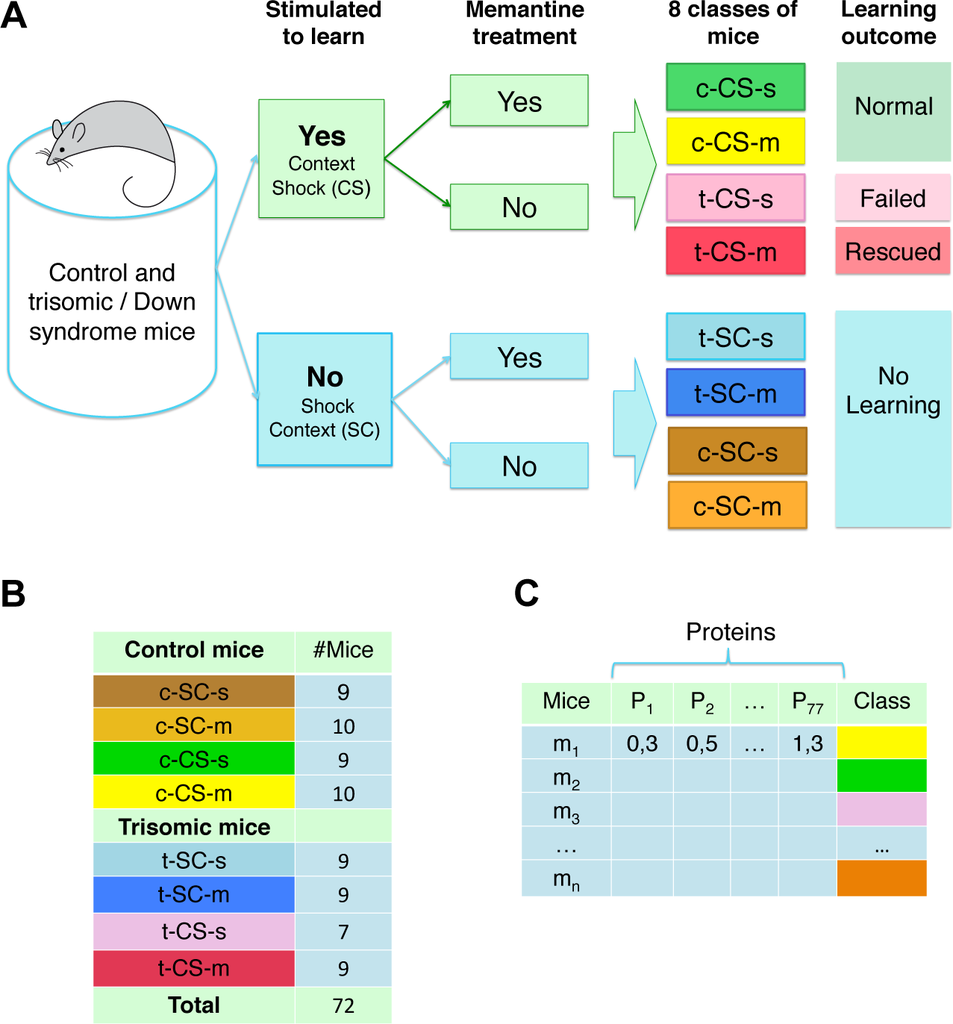

We will focus only on two classes: “t-CS-s”, “t-CS-m”. Moreover, each protein is measured in triplicates. There are specific statistical methods to handle triplicates that are out of the scope in this course. Therefore, we will adopt a very common and simple strategy used by basic scientists: average over the triplicates.

```r
dataset <- read_csv('data/cortex_nuclear.csv') %>% clean_names()
glimpse(dataset)
```

```
Rows: 1,080
Columns: 82
$ mouse_id         <chr> "309_1", "309_2", "309_3", "309_4", "309_5", "309_6",…
$ dyrk1a_n         <dbl> 0.5036439, 0.5146171, 0.5091831, 0.4421067, 0.4349402…
$ itsn1_n          <dbl> 0.7471932, 0.6890635, 0.7302468, 0.6170762, 0.6174298…
$ bdnf_n           <dbl> 0.4301753, 0.4117703, 0.4183088, 0.3586263, 0.3588022…
$ nr1_n            <dbl> 2.816329, 2.789514, 2.687201, 2.466947, 2.365785, 2.3…
$ nr2a_n           <dbl> 5.990152, 5.685038, 5.622059, 4.979503, 4.718679, 4.8…
$ p_akt_n          <dbl> 0.2188300, 0.2116362, 0.2090109, 0.2228858, 0.2131059…
$ p_braf_n         <dbl> 0.1775655, 0.1728170, 0.1757222, 0.1764626, 0.1736270…
$ p_camkii_n       <dbl> 2.373744, 2.292150, 2.283337, 2.152301, 2.134014, 2.1…
$ p_creb_n         <dbl> 0.2322238, 0.2269721, 0.2302468, 0.2070042, 0.1921579…
$ p_elk_n          <dbl> 1.750936, 1.596377, 1.561316, 1.595086, 1.504230, 1.4…
$ p_erk_n          <dbl> 0.6879062, 0.6950062, 0.6773484, 0.5832768, 0.5509601…
$ p_jnk_n          <dbl> 0.3063817, 0.2990511, 0.2912761, 0.2967287, 0.2869612…
```

[output cut: 69 more lines]

```r
dt <- dataset %>%
  separate(col = mouse_id,
           into = c("mouse_id", "replicate"), sep = "_") %>%
  group_by(mouse_id, genotype, treatment, behavior, class) %>%
  summarize(across(where(is.numeric), mean, na.rm = TRUE)) %>%
  arrange(., genotype, treatment, behavior, class) %>%
  ungroup() %>%
  filter(class == "t-CS-m" | class == "t-CS-s") %>%
  mutate(class = factor(class, levels = c("t-CS-s", "t-CS-m")
                        )
         )
```

[output not shown]

# Comparing two groups

```r
t.test(dyrk1a_n ~ class, data = dt)
```

```
    Welch Two Sample t-test

data:  dyrk1a_n by class
t = -1.4507, df = 12.781, p-value = 0.171
alternative hypothesis: true difference in means between group t-CS-s and group t-CS-m is not equal to 0
95 percent confidence interval:
 -0.23312987  0.04601195
sample estimates:
mean in group t-CS-s mean in group t-CS-m
           0.5257350            0.6192939
```

```r
t.test(itsn1_n ~ class, data = dt)
```

```
    Welch Two Sample t-test

data:  itsn1_n by class
t = -0.56208, df = 13.892, p-value = 0.583
alternative hypothesis: true difference in means between group t-CS-s and group t-CS-m is not equal to 0
95 percent confidence interval:
 -0.1804562  0.1055562
sample estimates:
mean in group t-CS-s mean in group t-CS-m
           0.7595565            0.7970065
```

```r
t.test(bdnf_n ~ class, data = dt)
```

```
    Welch Two Sample t-test

data:  bdnf_n by class
t = -0.41928, df = 13.132, p-value = 0.6818
alternative hypothesis: true difference in means between group t-CS-s and group t-CS-m is not equal to 0
95 percent confidence interval:
 -0.04470177  0.03015822
sample estimates:
mean in group t-CS-s mean in group t-CS-m
           0.3054604            0.3127322
```

Hovewer, it does not seem a very productive process because there are 77 proteins, and we will need to check the p-value of each test individually. Moreover, we did not even check the assumptions of the t-test.

## Lists

Lists are a class of objects in R that allow us to store other objects of different classes with different dimensions. Data frames are also a particular type of lists because allow us to store character, numeric, factor, logical vectors of the same length resulting in a rectangular shape object.

Many functions in R return lists as output that can be stored, even though their class is not explictly a list.

```r
my.test <- t.test(dyrk1a_n ~ class, data = dt)
class(my.test)
```

```
[1] "htest"
```

The function `ls` help us to find out the objects that are contained in a list. We can access these objects using $ similar to a data frame. These objects are often pieces presented in the visual output of the function.

```r
ls(my.test)
```

```
 [1] "alternative" "conf.int"    "data.name"   "estimate"    "method"
 [6] "null.value"  "p.value"     "parameter"   "statistic"   "stderr"
```

```r
my.test$conf.int
```

```
[1] -0.23312987  0.04601195
attr(,"conf.level")
[1] 0.95
```

```r
my.test$p.value
```

```
[1] 0.1709624
```

```r
my.test$method
```

```
[1] "Welch Two Sample t-test"
```

The ability to access individually objects for a procedure allow us to store only the information that we really need to perform our analysis.

```r
my.pvalue <- my.test$p.value
my.pvalue
```

```
[1] 0.1709624
```

```r
my.ci <- my.test$conf.int
my.ci
```

```
[1] -0.23312987  0.04601195
attr(,"conf.level")
[1] 0.95
```

```r
my.method <- my.test$method
my.method
```

```
[1] "Welch Two Sample t-test"
```

Now, we can create a data frame that will contain such objects.

```r
results <- data.frame(protein = NA, method = NA, difference = NA,
                  lower.ci = NA, upper.ci = NA, p.value = NA)
```

In this way, we can store only the objects that are useful for us.

```r
my.test <- t.test(dyrk1a_n ~ class, data = dt)
results[1, 'protein'] <- "dyrk1a_n"
results[1, 'method'] <- my.test$method
results[1, 'fold'] <- my.test$estimate[2]/my.test$estimate[1]
results[1, 'lower.ci'] <- my.test$conf.int[1]
results[1, 'upper.ci'] <- my.test$conf.int[2]
results[1, 'p.value'] <- my.test$p.value

my.test <- t.test(itsn1_n ~ class, data = dt)
results[2, 'protein'] <- "itsn1_n"
results[2, 'method'] <- my.test$method
results[2, 'fold'] <- my.test$estimate[2]/my.test$estimate[1]
results[2, 'lower.ci'] <- my.test$conf.int[1]
results[2, 'upper.ci'] <- my.test$conf.int[2]
results[2, 'p.value'] <- my.test$p.value

my.test <- t.test(bdnf_n ~ class, data = dt)
results[3, 'protein'] <- "itsn1_n"
results[3, 'method'] <- my.test$method
results[3, 'fold'] <- my.test$estimate[2]/my.test$estimate[1]
results[3, 'lower.ci'] <- my.test$conf.int[1]
results[3, 'upper.ci'] <- my.test$conf.int[2]
results[3, 'p.value'] <- my.test$p.value

results
```

```
   protein                  method difference    lower.ci   upper.ci   p.value
1 dyrk1a_n Welch Two Sample t-test         NA -0.23312987 0.04601195 0.1709624
2  itsn1_n Welch Two Sample t-test         NA -0.18045624 0.10555618 0.5830175
3  itsn1_n Welch Two Sample t-test         NA -0.04470177 0.03015822 0.6817885
      fold
1 1.177958
2 1.049305
3 1.023806
```

Even though we do not need to check each output individually, we still need to code our testing procedure for each protein. The procedure is the same for all proteins, i.e., we have a recipe for all of them.

How can we simplify this procedure?

## For loops

When we have repeated tasks, we can use for loop to execute a recipe several times.

```r
for (i in 1:10){
  i
  print(i)
}
```

```
[1] 1
[1] 2
[1] 3
[1] 4
[1] 5
[1] 6
[1] 7
[1] 8
[1] 9
[1] 10
```

The for loop is controlled by a counter that will help us to run our analysis for all the proteins.

Therefore, we need to choose the limits of our counter:

```r
names(dt)
```

```
 [1] "mouse_id"         "genotype"         "treatment"        "behavior"
 [5] "class"            "dyrk1a_n"         "itsn1_n"          "bdnf_n"
 [9] "nr1_n"            "nr2a_n"           "p_akt_n"          "p_braf_n"
[13] "p_camkii_n"       "p_creb_n"         "p_elk_n"          "p_erk_n"
[17] "p_jnk_n"          "pkca_n"           "p_mek_n"          "p_nr1_n"
[21] "p_nr2a_n"         "p_nr2b_n"         "p_pkcab_n"        "p_rsk_n"
[25] "akt_n"            "braf_n"           "camkii_n"         "creb_n"
[29] "elk_n"            "erk_n"            "gsk3b_n"          "jnk_n"
[33] "mek_n"            "trka_n"           "rsk_n"            "app_n"
[37] "bcatenin_n"       "sod1_n"           "mtor_n"           "p38_n"
[41] "p_mtor_n"         "dscr1_n"          "ampka_n"          "nr2b_n"
[45] "p_numb_n"         "raptor_n"         "tiam1_n"          "p_p70s6_n"
[49] "numb_n"           "p70s6_n"          "p_gsk3b_n"        "p_pkcg_n"
[53] "cdk5_n"           "s6_n"             "adarb1_n"         "acetyl_h3k9_n"
[57] "rrp1_n"           "bax_n"            "arc_n"            "erbb4_n"
[61] "n_nos_n"          "tau_n"            "gfap_n"           "glu_r3_n"
[65] "glu_r4_n"         "il1b_n"           "p3525_n"          "p_casp9_n"
[69] "psd95_n"          "snca_n"           "ubiquitin_n"      "p_gsk3b_tyr216_n"
[73] "shh_n"            "bad_n"            "bcl2_n"           "p_s6_n"
[77] "p_cfos_n"         "syp_n"            "h3ac_k18_n"       "egr1_n"
[81] "h3me_k4_n"        "ca_na_n"
```

```r
ncol(dt)
```

```
[1] 82
```

```r
protein_names <- names(dt)[6:82]
```

The second step is to incorporate the counter in our test procedure:

```r
# One way
t.test(dyrk1a_n ~ class, data = dt)
```

```
    Welch Two Sample t-test

data:  dyrk1a_n by class
t = -1.4507, df = 12.781, p-value = 0.171
alternative hypothesis: true difference in means between group t-CS-s and group t-CS-m is not equal to 0
95 percent confidence interval:
 -0.23312987  0.04601195
sample estimates:
mean in group t-CS-s mean in group t-CS-m
           0.5257350            0.6192939
```

```r
t.test(get(protein_names[1]) ~ class, data = dt)
```

```
    Welch Two Sample t-test

data:  get(protein_names[1]) by class
t = -1.4507, df = 12.781, p-value = 0.171
alternative hypothesis: true difference in means between group t-CS-s and group t-CS-m is not equal to 0
95 percent confidence interval:
 -0.23312987  0.04601195
sample estimates:
mean in group t-CS-s mean in group t-CS-m
           0.5257350            0.6192939
```

Finally, we can obtain t-test result for all proteins:

```r
for (i in 1:length(protein_names)){
  my.test <- t.test(get(protein_names[i]) ~ class, data = dt)
  results[i, 'protein'] <- names(dt)[i]
  results[i, 'method'] <- my.test$method
  results[i, 'fold'] <- my.test$estimate[2]/my.test$estimate[1]
  results[i, 'lower.ci'] <- my.test$conf.int[1]
  results[i, 'upper.ci'] <- my.test$conf.int[2]
  results[i, 'p.value'] <- my.test$p.value
}

results
```

```
            protein                  method difference      lower.ci
1          mouse_id Welch Two Sample t-test         NA -0.2331298679
2          genotype Welch Two Sample t-test         NA -0.1804562433
3         treatment Welch Two Sample t-test         NA -0.0447017691
4          behavior Welch Two Sample t-test         NA -0.2705101262
5             class Welch Two Sample t-test         NA -0.5979478852
6          dyrk1a_n Welch Two Sample t-test         NA -0.0346190608
7           itsn1_n Welch Two Sample t-test         NA -0.0269768286
8            bdnf_n Welch Two Sample t-test         NA -1.9282203775
9             nr1_n Welch Two Sample t-test         NA -0.0155205246
10           nr2a_n Welch Two Sample t-test         NA -0.2963585134
11          p_akt_n Welch Two Sample t-test         NA -0.3320380355
12         p_braf_n Welch Two Sample t-test         NA -0.0273300908
13       p_camkii_n Welch Two Sample t-test         NA -0.0739802326
14         p_creb_n Welch Two Sample t-test         NA -0.0392067366
```

[output cut: 141 more lines]

We can increase the complexity of our procedure such as including normality and homoscedasticity tests. Furthermore, we can replace the t-test for more conservative test such as Wilcox or Brunner-Munzel.

## Volcano plots

We often use a volcano plot to visualize p-values:

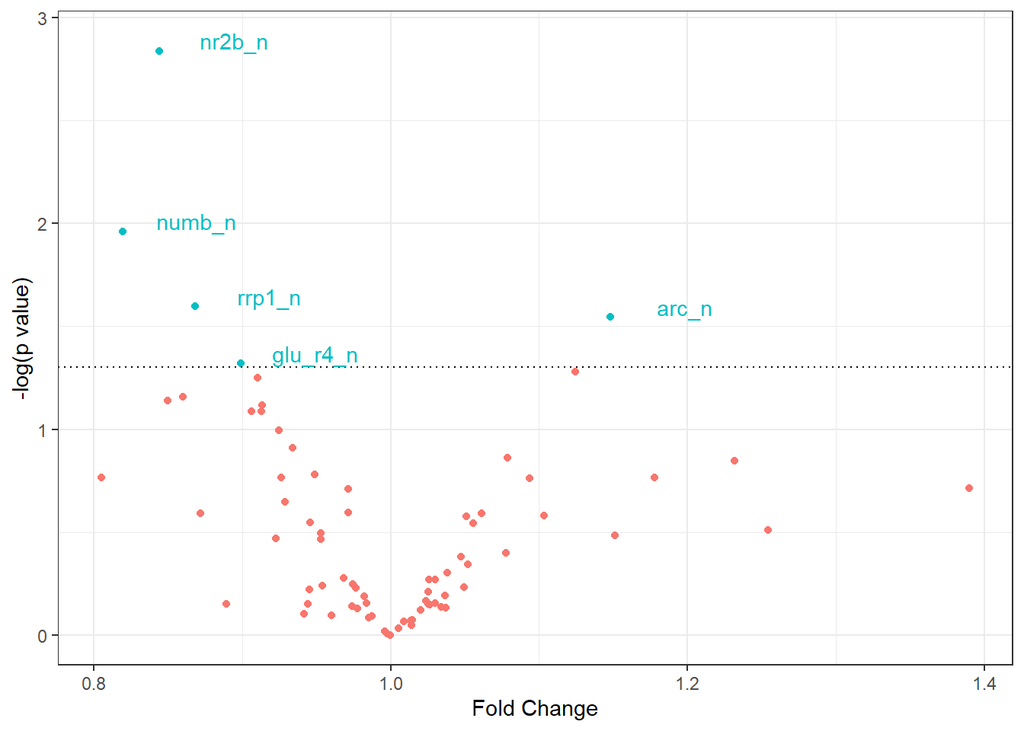

```r
results <- results %>%
  mutate(label = ifelse(p.value < 0.05, "S", "NS"),
                        log_pvalue = -log10(p.value))


ggplot(results, aes(x = fold, y = log_pvalue, color = label)) +
  geom_point() +
  geom_hline(yintercept = -log10(0.05), linetype = "dotted") +
  geom_text(data = results %>% filter(label == "S"),
            aes(x = fold, y = log_pvalue,
                label = protein),
            nudge_x = 0.05,
            nudge_y = 0.05) +
  labs(x = "Fold Change", y = "-log(p value)") +
  theme_bw() +
  theme(legend.position = "none")
```

If we want a box around the protein names:

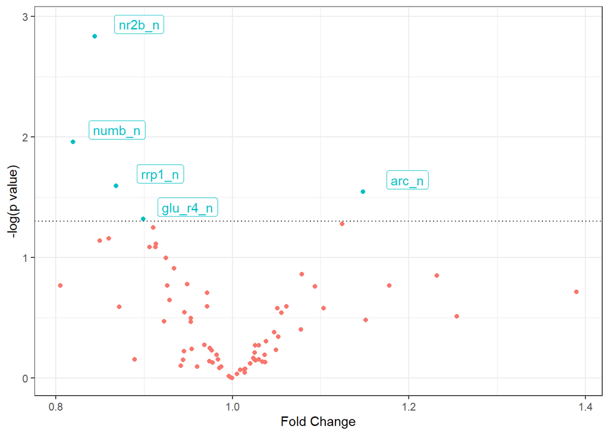

```r
ggplot(results, aes(x = fold, y = log_pvalue, color = label)) +
  geom_point() +
  geom_hline(yintercept = -log10(0.05), linetype = "dotted") +
  geom_label(data = results %>% filter(label == "S"),
            aes(x = fold, y = log_pvalue,
                label = protein),
            nudge_x = 0.05,
            nudge_y = 0.10) +
  labs(x = "Fold Change", y = "-log(p value)") +
  theme_bw() +
  theme(legend.position = "none")
```

### Multiple comparisons corrections

Do not forget to apply p value adjustments:

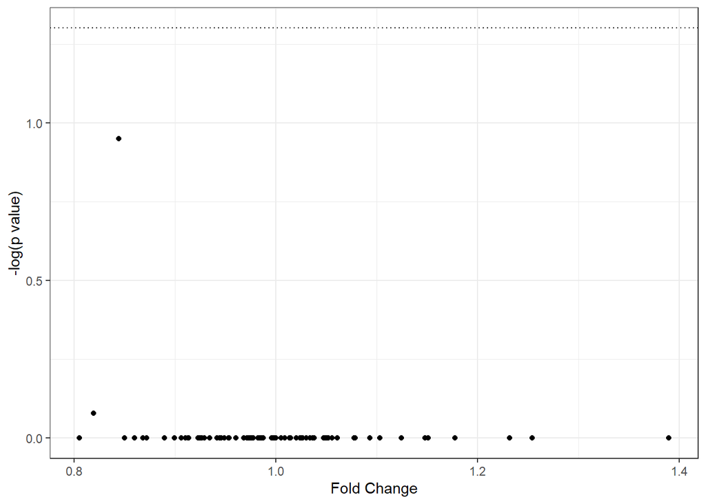

```r
results <- results %>%
  mutate(p.value_holm = p.adjust(p.value, method = "holm"),
         log_pvalue_holm = -log10(p.value_holm)) %>%
  mutate(p.value_fdr = p.adjust(p.value, method = "BH"),
         log_pvalue_fdr= -log10(p.value_fdr))


ggplot(results, aes(x = fold, y = log_pvalue_holm)) +
  geom_point() +
  geom_hline(yintercept = -log10(0.05), linetype = "dotted")  +
  labs(x = "Fold Change", y = "-log(p value)") +
  theme_bw() +
  theme(legend.position = "none")
```

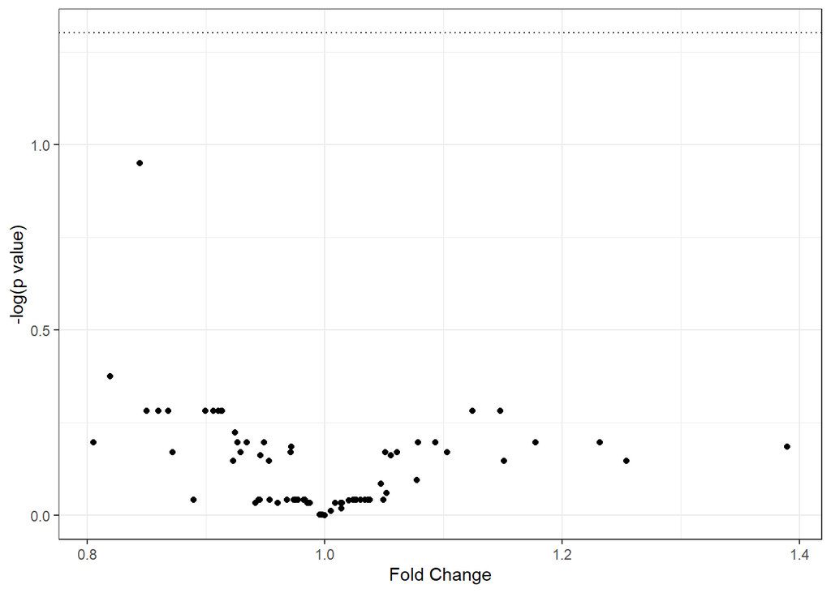

```r
ggplot(results, aes(x = fold, y = log_pvalue_fdr)) +
  geom_point() +
  geom_hline(yintercept = -log10(0.05), linetype = "dotted")  +
  labs(x = "Fold Change", y = "-log(p value)") +
  theme_bw() +
  theme(legend.position = "none")
```

Holm’s correction controls the Family Wise Error Rate (FWER), consequently, it also controls the False Discovery Rate (FDR). However, Benjamin and Hochberg’s correction only controls FDR, which might be acceptable if validation experiments are planned.